# Parameter Estimation – Wild Fish Catch

ESM 244 - Assignment 4 Task 2

Minnie Ringland

March 8, 2021

#### About the Data

Today, we’ll explore trends in wild fish catch and aquaculture production around the world over the last 60-70 years. The Earth Policy Institute compiled data collected by the United Nations Food and Agriculture Organization, Fisheries Division. Fish data include fishes, crustaceans, mollusks, and various other aquatic animals. We use the total global catch, from all countries, from 1950-2012, divided according to whether the fish were wild or farmed.

#### Preliminary Data Exploration

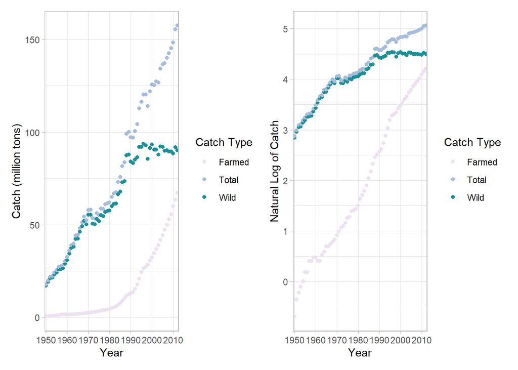

```r
# Read in data
global_catch <- read_csv("fish_catch.csv") %>%
  rename("Year"=1, "Wild"=2, "Farmed"=3, "Total"=4) %>%
  slice(5:67) %>%
  mutate(Wild = as.numeric(Wild), Farmed = as.numeric(Farmed), Total=as.numeric(Total))

global_catch_long <- global_catch %>%
  pivot_longer(cols = Wild:Total, names_to = "Catch")

p1 <- ggplot(data=global_catch_long) +
  geom_point(aes(x=Year, y=value, color = Catch)) +
  scale_x_discrete(breaks=seq(1950, 2020, by = 10)) +
  scale_color_brewer(palette = 10) +
  labs(y = "Catch (million tons)", color = "Catch Type") +
  theme_light()

p2 <- ggplot(data=global_catch_long) +
  geom_point(aes(x=Year, y=log(value), color = Catch)) +
  scale_x_discrete(breaks=seq(1950, 2020, by = 10)) +
  scale_color_brewer(palette = 10) +
  labs(y = "Natural Log of Catch", color = "Catch Type") +
  theme_light()

(p1 + p2) & theme_light()
```

We see that for farmed fish, there is exponential growth in the catch over time. The wild catch looks more linear but then plateaus. When we plot the natural log of catch, we see a logistic growth-type curve for the wild catch. The logistic growth equation is:

$P(t)=\frac{K}{1+Ae^{-kt}}$, where

- $K$ is the carrying capacity
- $A$ is $\frac{K-P_0}{P_0}$
- $k$ is the growth rate constant

#### Find initial estimates for *K*, *A* and *k*

Let’s estimate the growth constant during the curve’s exponential phase (to get a starting-point guess for *k*):

```r
# Reset years
catch_years <- global_catch %>%
  select(Year, Wild) %>%
  mutate(Year = as.numeric(Year)) %>%
  mutate(year_new = Year - min(Year))

# Select only exponential growth phase and log-transform
catch_exp <- catch_years %>%
  filter(year_new < 40) %>%
  mutate(ln_catch = log(Wild))

catch_exp2 <- catch_years %>%
  filter(year_new <= 40 & year_new >= 20) %>%
  mutate(ln_catch = log(Wild))

# Model linear to get *k* estimate (the slope of this linear equation is an estimate of the growth rate constant):
lm_k <- lm(ln_catch ~ year_new, data = catch_exp)
#lm_k2 <- lm(ln_catch ~ year_new, data = catch_exp2)
# This gives the same parameter estimates as the full 40 year span estimate

K_est <- exp(4.5)
A_est <- (K_est - catch_years$Wild[1])/(catch_years$Wild[1])
#
```

Looking at just 1950-1990, the growth rate constant is estimated by a linear model to be 0.035623.

#### Estimate parameters using onlinear least squares (NLS)

We’ll use the most common algorithm - Gauss-Newton - to converge on parameter estimates that minimize the the sum of squares of residuals.

```r
catch_nls <- nls(Wild ~ K/(1 + A*exp(-r*year_new)),
              data = catch_years,
              start = list(K = K_est, A = A_est, r = lm_k$coefficients[2]),
)

# See the model summary (null hypothesis: parameter value = 0)
#summary(catch_nls)

# Use broom:: functions to get model outputs in tidier format:
model_out <- broom::tidy(catch_nls) # Use View(model_out) to see the tidy model output.

model_out %>%
  gt() %>%
  tab_header(title = "Gauss-Newton NLS Parameter Estimates") %>%
  cols_label(
    estimate = "Estimate",
    std.error = "Standard Error",
    statistic = "Statistic",
    p.value = "P-Value"
  )
```

Gauss-Newton NLS Parameter Estimates

| term | Estimate | Standard Error | Statistic | P-Value |
| --- | --- | --- | --- | --- |
| K | 100.27848104 | 2.734151454 | 36.67627 | 8.572080e-43 |
| A | 4.31632476 | 0.292939820 | 14.73451 | 1.340590e-21 |
| r | 0.06988665 | 0.004648175 | 15.03529 | 5.142324e-22 |

#### Visualize prediction

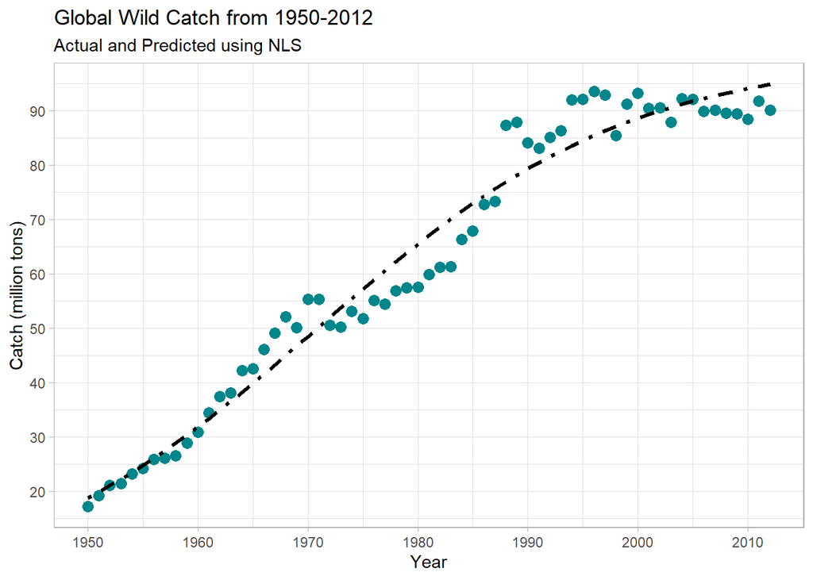

```r
# Make predictions for the population at all of those times (time) in the original df:
catch_predict <- predict(catch_nls)

# Bind predictions to original data frame:
catch_complete <- data.frame(catch_years, catch_predict)

# Plot them all together:
ggplot(data = catch_complete, aes(x = Year, y = Wild)) +
  geom_point(color="turquoise4", size=3) +
  geom_line(aes(x = Year, y = catch_predict), size=1.2, linetype="dotdash") +
  scale_x_continuous(breaks=seq(1950, 2020, by = 10)) +
  scale_y_continuous(breaks=seq(0, 120, by = 10)) +
  labs(y = "Catch (million tons)", title = "Global Wild Catch from 1950-2012", subtitle="Actual and Predicted using NLS") +
  theme_light()
```

*Data Source:*  
Global wild fish catch and aquaculture production, compiled by Earth Policy Institute with 1950-2010 from U.N. Food and Agriculture Organization (FAO), Global Capture Production and Global Aquaculture Production, electronic databases, at www.fao.org/fishery/topic/16140/en.